# 02_Analytic_Accuracy

Adam Dziorny

2022-10-05

## Overview

The purpose of this markdown is to report analytic accuracy by calculating the counts of simultaneous pairs, distributions across those pairs, correlation, and Bland-Altman analysis. Also includes the time-to-result numbers and figure.

## Initialize

First we load the necessary packages:

```r
suppressPackageStartupMessages({

  # Data frame manipulation
  require(dplyr)

  # Graphics and output
  require(ggplot2)

  # Bland Altman
  require(BlandAltmanLeh)
})
```

Ensure the environmental variables are specified:

```r
if (Sys.getenv('PICU_LAB_DATA_PATH') == '' |
    Sys.getenv('PICU_LAB_IMG_PATH') == '' |
    Sys.getenv('PICU_LAB_IN_FILE') == '' |
    Sys.getenv('PICU_LAB_SITE_NAME') == '' |
    Sys.getenv('PICU_LAB_RUN_DATE') == '')
  stop('Missing necessary environmental variables - see README.md')

cat(sprintf('Site: %s\n', Sys.getenv('PICU_LAB_SITE_NAME')))
```

```
## Site: URMC
```

Specify the run date:

```r
run.date <- Sys.getenv('PICU_LAB_RUN_DATE')

cat(sprintf('Run Date: %s\n', run.date))
```

```
## Run Date: 2022-12-22
```

## Data Input

Load data from the `DATA_PATH` with the associated `IN_FILE`, adding a file separator between them. This should result in loading two data frames: `cohort.df` and `labs.df`.

```r
load(
  file = file.path(
    Sys.getenv('PICU_LAB_DATA_PATH'),
    Sys.getenv('PICU_LAB_IN_FILE')
  )
)
```

## Set Parameters

We will utilize several sensitivity analyses in this markdown. To simplify, we set several parameters ahead of time and then run through those parameters below.

```r
# The primary cutoff value between collection times (in minutes) to
# determine "simultaneous"
primary.cutoff <- 15.

# Sensitivity analysis list
sens.cutoffs <- c(1., 30., 90.)
```

## Join

First we create the joined dataset to represent simultaneously obtained lab values. We need to allow the specifying of the two `PROC_NAME` comparators from the list - `CBC`, `BG`, or `ISTAT`. We also need to include several parameters that can be adjusted to reflect sensitivity analyses:

- Collection time difference (in minutes)
- Single (index) versus multiple simultaneous values per patient
- Encounter Key (needed to join multiple panels with different `ORDER_PROC_KEY` values)

We will remove non-numeric rows, as there is no sensitivity analysis to do with these but rather we have reported their counts already. Below is the function to be used (note that this may be duplicated in other Rmarkdown files - changes should be made *here* and not in other files):

```r
#'
#' @title Create Paired Dataset
#'
#' @description Creates a dataset of paired simultaneous lab values
#'
#' @param labs.df The labs data frame
#' @param cohort.df The cohort data frame, needed for PAT_KEY and DEPT
#' @param PN A two-element list of PROC_NAMEs to join
#' @param time.diff The max time difference (min) between collected times
#' @param CN The COMP_NAME to join [Default: 'Hgb']
#' @param multi.per.pt If FALSE, limit to first result per patient, otherwise
#'     if TRUE [Default], allow all
#'
#' @returns The resulting joined data frame
#'
createPairedDataset <- function (labs.df, cohort.df, PN, time.diff,
                           CN = 'Hgb', multi.per.pt = T) {

  # First we filter to remove the non-numeric rows
  filter.df <-
    labs.df %>%
    dplyr::filter(!is.na(NUM_VAL) & NUM_VAL != 9999999.) %>%
    dplyr::filter(COMP_NAME == CN)

  cat(sprintf('Number of component numeric rows in input data frame: %d\n',
              nrow(filter.df)))

  # Join to get PAT_KEY and DEPT, used in subsequent filtering
  keyed.df <-
    dplyr::left_join(
      x = filter.df,
      y = cohort.df %>%
        dplyr::select(ENC_KEY, PAT_KEY, DEPT),
      by = c('ENC_KEY')
    )

  # Now we filter by PN and join to create full data frame
  joined.df <-
    dplyr::inner_join(
      x = keyed.df %>%
        dplyr::filter(PROC_NAME == PN[1]) %>%
        dplyr::select(ENC_KEY, PAT_KEY, ORDER_PROC_KEY,
                      DEPT, COLLECTED_DT, RESULT_DT, NUM_VAL, AGE_PROC),
      y = keyed.df %>%
        dplyr::filter(PROC_NAME == PN[2]) %>%
        dplyr::select(ENC_KEY, PAT_KEY, ORDER_PROC_KEY,
                      DEPT, COLLECTED_DT, RESULT_DT, NUM_VAL),
      by = c('ENC_KEY', 'PAT_KEY', 'DEPT'),
      suffix = c('.x', '.y')
    )

  # Join using base R, by column number
  #   [[5]] is PN[1] COLLECTED_DT
  #   [[10]] is PN[2] COLLECTED_DT
  joined.df$COLL_TIME_DIFF_MIN <-
    as.numeric(joined.df[[5]] - joined.df[[10]], units = 'mins')

  # Apply the cutoff time
  cutoff.df <-
    joined.df %>%
    dplyr::filter(abs(COLL_TIME_DIFF_MIN) < time.diff)

  cat(sprintf('Number of paired, simultaneous values meeting cutoff: %d\n',
              nrow(cutoff.df)))

  # Ensure that each first PROC_NAME order is only used once - meaning that
  # each ORDER_PROC_KEY.x should be unique
  unique.x.df <-
    cutoff.df%>%
    dplyr::arrange(ORDER_PROC_KEY.x, COLL_TIME_DIFF_MIN) %>%
    dplyr::group_by(ORDER_PROC_KEY.x) %>%
    dplyr::summarize(
      ORDER_PROC_KEY.y   = first( ORDER_PROC_KEY.y   ),
      DEPT               = first( DEPT               ),
      COLLECTED_DT.x     = first( COLLECTED_DT.x     ),
      RESULT_DT.x        = first( RESULT_DT.x        ),
      NUM_VAL.x          = first( NUM_VAL.x          ),
      COLLECTED_DT.y     = first( COLLECTED_DT.y     ),
      RESULT_DT.y        = first( RESULT_DT.y        ),
      NUM_VAL.y          = first( NUM_VAL.y          ),
      COLL_TIME_DIFF_MIN = first( COLL_TIME_DIFF_MIN ),
      AGE_PROC           = first( AGE_PROC           ),
      ENC_KEY            = first( ENC_KEY            ),
      PAT_KEY            = first( PAT_KEY            )
    ) %>%
    dplyr::ungroup()

  cat(sprintf('Number of non-duplicated first PROC_NAME rows: %d\n',
              nrow(unique.x.df)))

  # Similarly, ensure that each second PROC_NAME order is being used just once
  # (i.e., that ORDER_PROC_KEY.y is not duplicated)
  non.dup.df <-
    unique.x.df %>%
    dplyr::arrange(ORDER_PROC_KEY.y, COLL_TIME_DIFF_MIN) %>%
    dplyr::group_by(ORDER_PROC_KEY.y) %>%
    dplyr::summarize(
      ORDER_PROC_KEY.x   = first( ORDER_PROC_KEY.x   ),
      DEPT               = first( DEPT               ),
      COLLECTED_DT.x     = first( COLLECTED_DT.x     ),
      RESULT_DT.x        = first( RESULT_DT.x        ),
      NUM_VAL.x          = first( NUM_VAL.x          ),
      COLLECTED_DT.y     = first( COLLECTED_DT.y     ),
      RESULT_DT.y        = first( RESULT_DT.y        ),
      NUM_VAL.y          = first( NUM_VAL.y          ),
      COLL_TIME_DIFF_MIN = first( COLL_TIME_DIFF_MIN ),
      AGE_PROC           = first( AGE_PROC           ),
      ENC_KEY            = first( ENC_KEY            ),
      PAT_KEY            = first( PAT_KEY            )
    ) %>%
    dplyr::ungroup()

  cat(sprintf('Number of non-duplicated second PROC_NAME rows: %d\n',
              nrow(non.dup.df)))

  # Do we limit by one per patient?
  if (!multi.per.pt) {
    per.pt.df <-
      non.dup.df %>%
      # Sort by PAT_KEY and the first COLLECTED DT
      dplyr::arrange(PAT_KEY, COLLECTED_DT.x) %>%
      # Group by PAT_KEY and add a "LINE" number
      dplyr::group_by(PAT_KEY) %>%
      dplyr::mutate(
        PAT_LINE = row_number()
      ) %>%
      # Ungroup
      dplyr::ungroup() %>%
      # Filter for lines == 1 only
      dplyr::filter(PAT_LINE == 1) %>%
      dplyr::select(-PAT_LINE)
  } else {
    per.pt.df <- non.dup.df
  }

  cat(sprintf('Number of paired, simultaneous values: %d\n',
              nrow(per.pt.df)))

  cat(sprintf('Number of duplicated ORDER_PROC_KEY.x values: %d\n',
              sum(duplicated(per.pt.df$ORDER_PROC_KEY.x))))

  return(per.pt.df)
}
```

First we create the CBC - BG dataset using the primary cutoff value, and include all pairs per patient.

```r
cbc.bg <- createPairedDataset(
  labs.df = labs.df,
  cohort.df = cohort.df,
  PN = c('CBC', 'BG'),
  CN = 'Hgb',
  time.diff = primary.cutoff,
  multi.per.pt = T
)
```

```
## Number of component numeric rows in input data frame: 173682
## Number of paired, simultaneous values meeting cutoff: 19532
## Number of non-duplicated first PROC_NAME rows: 18684
## Number of non-duplicated second PROC_NAME rows: 18680
## Number of paired, simultaneous values: 18680
## Number of duplicated ORDER_PROC_KEY.x values: 0
```

## Analyze

From this dataset we can get counts of lab values per DEPT:

```r
table(cbc.bg$DEPT)
```

```
##
##  CICU  PICU
## 12618  6062
```

### Distributions

Now we describe the distributions:

```r
#'
#' @title Describe Paired Distributions
#'
#' @description Descriptive statistics, QQ plots, density plot, and TTest
#'
#' @param df The paired data frame of interest
#' @param PN A 2-element list (matching that from above) of the PROC_NAMEs
#' @param paired.t If TRUE [Default], uses paired t test
#' @param to.return If TRUE, returns list of results; otherwise returns NULL [Default]
#'
#' @returns Pending the above flag, either NULL or list of graphics and t test
#'
describePairedDistributions <- function (df, PN,
                                         paired.t = T, to.return = F) {

  cat(sprintf('Summary of %s values:\n', PN[1]))
  print(summary(df$NUM_VAL.x))
  cat(sprintf('SD: %0.2f\n', sd(df$NUM_VAL.x)))

  # QQ Plot
  p1 <-
    df %>%
    ggplot(aes(sample = NUM_VAL.x)) +
    stat_qq() +
    ggtitle(paste0('Lab Value Distribution QQ Plot: ',PN[1])) +
    theme_bw()

  print(p1)

  cat(sprintf('Summary of %s values:\n', PN[2]))
  print(summary(df$NUM_VAL.y))
  cat(sprintf('SD: %0.2f\n', sd(df$NUM_VAL.y)))

  # QQ Plot
  p2 <-
    df %>%
    ggplot(aes(sample = NUM_VAL.y)) +
    stat_qq() +
    ggtitle(paste0('Lab Value Distribution QQ Plot: ',PN[2])) +
    theme_bw()

  print(p2)

  # Create Density Plot
  Density <-
    rbind(
      data.frame(
        df %>%
          dplyr::select(NUM_VAL.x) %>%
          dplyr::rename(val = NUM_VAL.x),
        src = PN[1]),
      data.frame(
        df %>%
          dplyr::select(NUM_VAL.y) %>%
          dplyr::rename(val = NUM_VAL.y),
        src = PN[2])
    ) %>%
    ggplot() +
    geom_density(aes(x = val, fill = src), alpha = 0.5) +
    scale_fill_brewer(type = 'qual', palette = 6) +
    labs(fill = 'Source') +
    xlab('Hemoglobin (g/dL)') +
    ylab('Density (Distribution)') +
    theme_bw()

  print(Density)

  # Paired T-Test
  t.res <-
    t.test(
      x = df$NUM_VAL.x,
      y = df$NUM_VAL.y,
      alternative = 'two.sided',
      paired = TRUE
    )

  print(t.res)

  # Return
  if (to.return) {
    return(list(
      qq.p = list(p1, p2),
      density.p = Density,
      t.test = t.res
    ))
  } else {
    return()
  }
}
```

Describe the primary paired distribution and capture the results, as we will have to save out these images for compilation with other sites.

```r
paired.res <- describePairedDistributions(
  df = cbc.bg,
  PN = c('CBC', 'BG'),
  paired.t = T,
  to.return = T
)
```

```
## Summary of CBC values:
##    Min. 1st Qu.  Median    Mean 3rd Qu.    Max.
##    3.00    8.90   10.20   10.37   11.60   20.80
## SD: 1.99
```

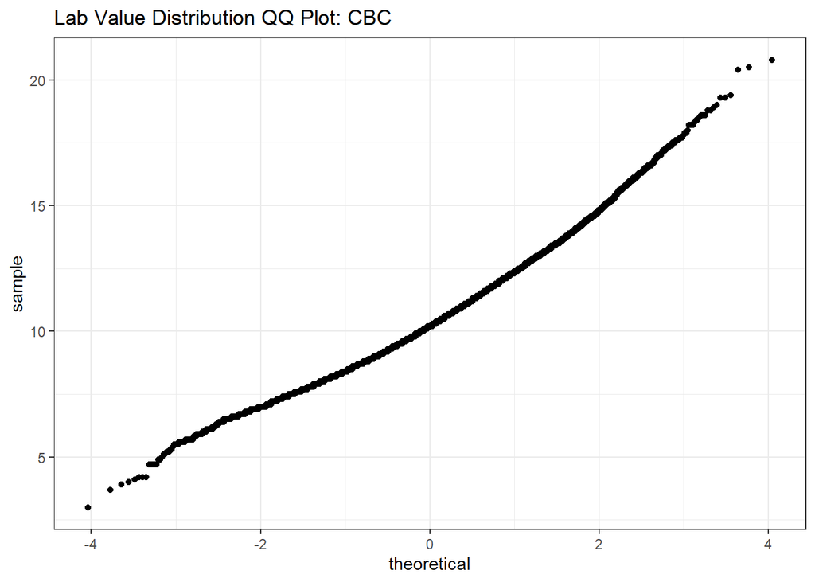

```
## Summary of BG values:
##    Min. 1st Qu.  Median    Mean 3rd Qu.    Max.
##     2.0     9.4    10.7    10.8    12.0    21.8
## SD: 1.99
```

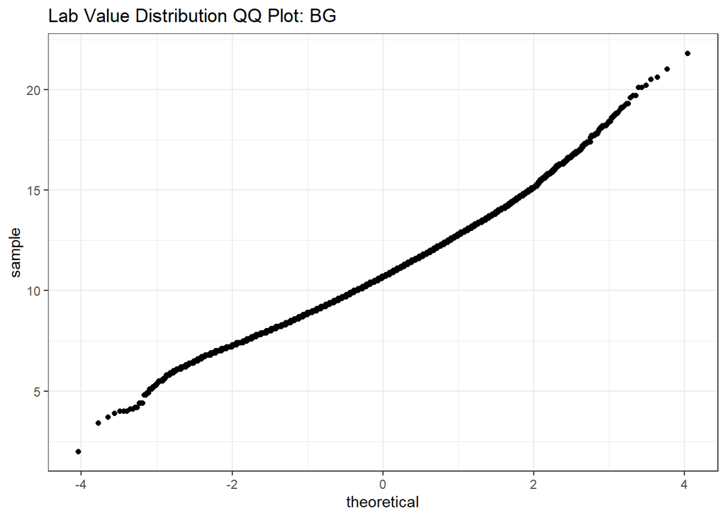

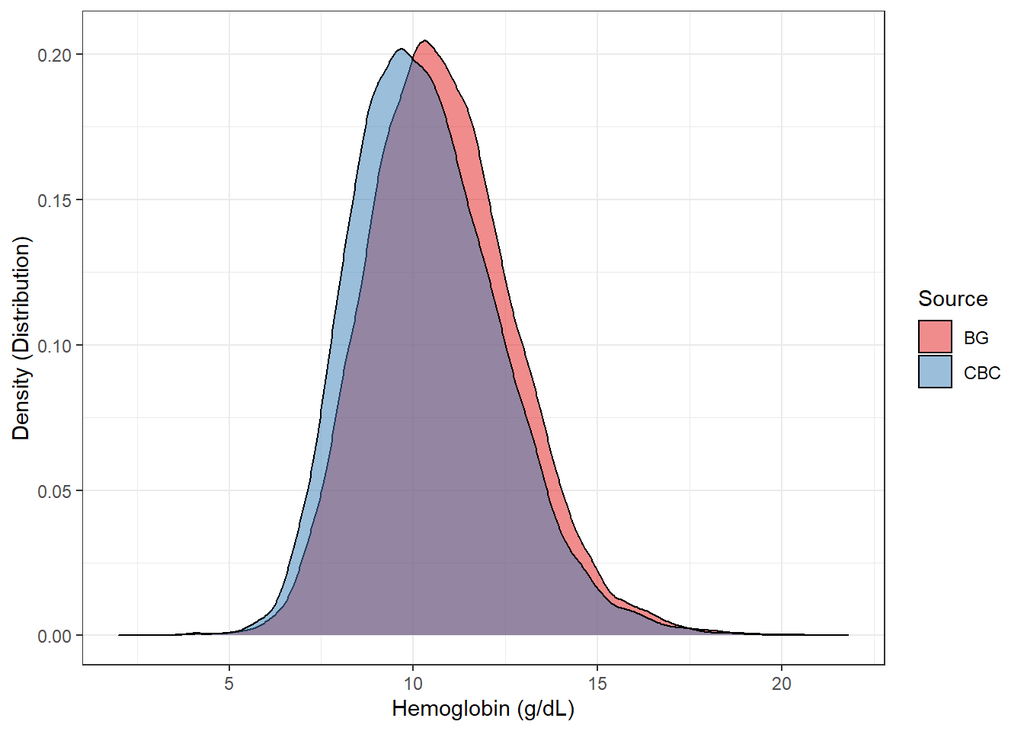

```
##
##  Paired t-test
##
## data:  df$NUM_VAL.x and df$NUM_VAL.y
## t = -93.921, df = 18679, p-value < 2.2e-16
## alternative hypothesis: true difference in means is not equal to 0
## 95 percent confidence interval:
##  -0.440668 -0.422651
## sample estimates:
## mean of the differences
##              -0.4316595
```

### Correlation

Now we evaluate the correlation among these paired values:

```r
#'
#' @title Determine Correlation
#'
#' @description Determine the Pearson Correlation among pairs by DEPT
#'
#' @param df The labs data frame
#' @param DPT Either a single DEPT value or a list of values
#'
#' @returns A list of results containing cor estimates, CI, sample size
#'
determineCorrelation <- function (df, DPT) {

  # Filter by the department of interest first
  limited.df <-
    df %>%
    dplyr::filter(DEPT %in% DPT)

  cat(sprintf('Number of rows from which correlation is calculated: %d\n',
              nrow(limited.df)))

  # Calculated from cor, with CIs calculated manually
  cat(sprintf('First we use `cor` function to calculate:\n'))

  R <- cor(limited.df$NUM_VAL.x,limited.df$NUM_VAL.y)
  R2 <- R * R

  cat(sprintf('\tCorrelation (R): %0.4f\tR^2: %0.4f\n',
              R, R2))

  n <- nrow(limited.df)
  k <- 2

  SE <- sqrt((4*R2*((1-R2)**2)*((n-k-1)**2))/((n**2-1)*(n + 3)))

  cat(sprintf('\tCI: Lower: %0.4f\tUpper: %0.4f\n',
              R2 - 2*SE, R2 + 2*SE))

  # Calculated from cor.test
  cat(sprintf('Now we use `cor.test` and `conf.int` to calculate:\n'))

  cor.res <-
    cor.test(
      x = limited.df$NUM_VAL.x,
      y = limited.df$NUM_VAL.y,
      alternative = 'two.sided',
      method = 'pearson'
    )

  cat(sprintf('\tCalculated R: %0.4f\tR^2: %0.4f\n',
              cor.res$estimate,
              cor.res$estimate * cor.res$estimate))

  cat(sprintf('\tCalulated CIs: Lower: %0.4f\tUpper: %0.4f\n',
              cor.res$conf.int[1]*cor.res$conf.int[1],
              cor.res$conf.int[2]*cor.res$conf.int[2]))

  return(list(
    cor.est = cor.res$estimate,
    cor.conf.int = cor.res$conf.int,
    dept = DPT,
    n = nrow(limited.df)
  ))
}
```

Now we compute the Pearson correlations among all pairs, and then subsequently among the different departments. These will be saved out later for comparison between institutions.

```r
pcc.cbc.bg <- determineCorrelation(cbc.bg, c('PICU', 'CICU'))
```

```
## Number of rows from which correlation is calculated: 18680
## First we use `cor` function to calculate:
##  Correlation (R): 0.9503 R^2: 0.9030
##  CI: Lower: 0.9003   Upper: 0.9057
## Now we use `cor.test` and `conf.int` to calculate:
##  Calculated R: 0.9503    R^2: 0.9030
##  Calulated CIs: Lower: 0.9003    Upper: 0.9056
```

```r
pcc.cbc.bg.picu <- determineCorrelation(cbc.bg, 'PICU')
```

```
## Number of rows from which correlation is calculated: 6062
## First we use `cor` function to calculate:
##  Correlation (R): 0.9434 R^2: 0.8900
##  CI: Lower: 0.8846   Upper: 0.8953
## Now we use `cor.test` and `conf.int` to calculate:
##  Calculated R: 0.9434    R^2: 0.8900
##  Calulated CIs: Lower: 0.8846    Upper: 0.8951
```

```r
pcc.cbc.bg.cicu <- determineCorrelation(cbc.bg, 'CICU')
```

```
## Number of rows from which correlation is calculated: 12618
## First we use `cor` function to calculate:
##  Correlation (R): 0.9477 R^2: 0.8982
##  CI: Lower: 0.8947   Upper: 0.9016
## Now we use `cor.test` and `conf.int` to calculate:
##  Calculated R: 0.9477    R^2: 0.8982
##  Calulated CIs: Lower: 0.8948    Upper: 0.9015
```

We can compare Pearson correlation coefficients using this function:

```r
#'
#' @title Compare Pearson Correlations
#'
#' @description Use the Fisher's R to Z transformation and return significance
#'
#' @param r1 The R value from the first independent correlation
#' @param n1 The sample size of the first correlation
#' @param r2 The R value from the second independent correlation
#' @param n2 The sample size of the second correlation
#'
#' @returns The p-value
#'
#'
comparePearsonCorrelations <- function (r1, n1, r2, n2) {

  z1 <- atanh(r1)

  z2 <- atanh(r2)

  zobs <- (z1-z2) / sqrt( 1 / (n1-3) + 1 / (n2-3) )

  pval <- 2 * pnorm(-abs(zobs))

  return(pval)
}
```

Compare PICU vs CICU correlations:

```r
cat(sprintf('PICU (R: %0.4f) vs CICU (R: %0.4f): %0.4f\n',
            pcc.cbc.bg.picu$cor.est,
            pcc.cbc.bg.cicu$cor.est,
            comparePearsonCorrelations(
              r1 = pcc.cbc.bg.picu$cor.est,
              n1 = pcc.cbc.bg.picu$n,
              r2 = pcc.cbc.bg.cicu$cor.est,
              n2 = pcc.cbc.bg.cicu$n
            )))
```

```
## PICU (R: 0.9434) vs CICU (R: 0.9477): 0.0087
```

### Bland-Altman Analysis

In this section we make use of the package `BlandAltmanLeh` to perform the calculations and generate the statistical results.

```r
#'
#' @title Perform Bland Altman Analysis
#'
#' @description Calculates Bland-Altman statistics and generates plots
#'
#' @param df The data frame of paired values
#' @param PN A 2-element list of the PROC Names for comparison
#' @param DPT A list or single value of the departments of interest
#' @param pt.size The point size for plotting the B-A plots [Default: 0.8]
#' @param to.graph If TRUE [Default], displays BA plots
#' @param to.return If TRUE [Default], returns a list of elements including:
#'
#' @returns Either a list as denoted above, or NULL if `to.return` is FALSE
#'
performBlandAltmanANalysis <- function (df, PN, DPT, pt.size = 0.8,
                                        to.graph = T, to.return = T,
                                        non.param = NA) {

  # Filter by the department of interest first
  limited.df <-
    df %>%
    dplyr::filter(DEPT %in% DPT) %>%
    dplyr::mutate(
      diff = NUM_VAL.x - NUM_VAL.y
    ) %>%
    dplyr::arrange(diff)

  cat(sprintf('Number of rows from which correlation is calculated: %d\n',
              nrow(limited.df)))

  # If percentile ranges are given for non-parametric BA, trim data:
  if (any(!is.na(non.param))) {

    if (length(non.param) != 2)
      stop('If non.param is specified, must be length == 2')

    # Calculate lower and upper quantiles at the specified probabilities
    lower <- quantile(limited.df$diff, probs = non.param[1])
    upper <- quantile(limited.df$diff, probs = non.param[2])

    # Keep only those rows where the diff falls within lower and upper
    limited.df <-
      limited.df %>%
      dplyr::filter(
        diff >= lower & diff <= upper
      )

    cat(sprintf('Lower %0.2f %%: %0.3f\tUpper %0.2f %%: %0.3f\n',
                non.param[1] * 100., lower,
                non.param[2] * 100., upper))

    cat(sprintf('New number of rows: %d\n', nrow(limited.df)))
  }

  # QQ Plot of mean differences
  p.qq <-
    limited.df %>%
    ggplot(aes(sample = diff)) +
    stat_qq() +
    ggtitle('QQ Plot of Differences') +
    theme_bw()

  if (to.graph)
    print(p.qq)

  # Do not use a test for normality unless number of samples < 5000
  if (nrow(limited.df) < 5000) {
    print( shapiro.test(limited.df$diff) )
  }

  # For ease of subsequent coding, rename vectors:
  x <- limited.df$NUM_VAL.x
  y <- limited.df$NUM_VAL.y

  # Run the BA statistics
  stats <-
    BlandAltmanLeh::bland.altman.stats(
      group1 = x,
      group2 = y
    )

  # Display results
  cat(sprintf('B-A Analysis of %s - %s in DEPT %s\n',
              PN[1],PN[2],DPT))

  cat(sprintf('\tMean difference (bias): %0.4f\n',
              stats$mean.diffs))

  cat(sprintf('Limits: [%0.2f, %0.2f]\n',
              stats$lower.limit, stats$upper.limit))

  cat(sprintf('CIs of mean and limits:\n'))
  print(stats$CI.lines)

  # Make Graph
  mean.diff <- mean( x - y )
  sd.diff <- sd( x - y )

  p <-
    ggplot() +
    geom_point(aes(x = (x + y) / 2., y = (x - y)), size = pt.size) +
    geom_hline(aes(yintercept = mean.diff), color = 'blue', size = 0.5) +
    geom_hline(aes(yintercept = mean.diff + (1.96 * sd.diff)),
               color = 'red', linetype = 'dashed', size = 0.5) +
    geom_hline(aes(yintercept = mean.diff - (1.96 * sd.diff)),
               color = 'red', linetype = 'dashed', size = 0.5) +
    xlab('Average Value') +
    ylab('Difference') +
    theme_bw()

  if (to.graph) {
    print(p)
  }

  # Return
  if (to.return) {
    return(
      list(
        stats = stats,
        plot = p,
        qq.plot = p.qq
      ))
  } else {
    return()
  }
}
```

Perform Bland-Altman, split by department:

```
## Number of rows from which correlation is calculated: 18680
```

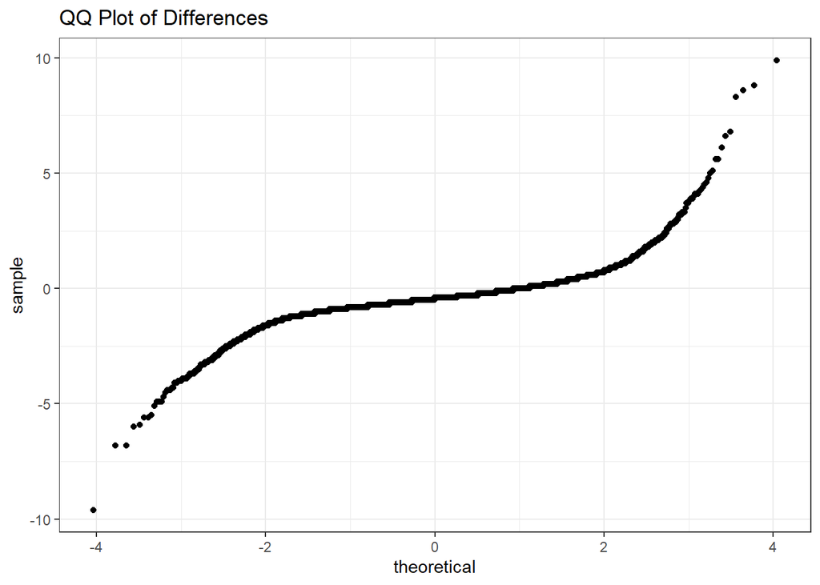

```
## B-A Analysis of CBC - BG in DEPT PICU
##  B-A Analysis of CBC - BG in DEPT CICU
##  Mean difference (bias): -0.4317
## Limits: [-1.66, 0.80]
## CIs of mean and limits:
## lower.limit.ci.lower lower.limit.ci.upper   mean.diff.ci.lower
##           -1.6784433           -1.6472369           -0.4406680
##   mean.diff.ci.upper upper.limit.ci.lower upper.limit.ci.upper
##           -0.4226510            0.7839178            0.8151242
```

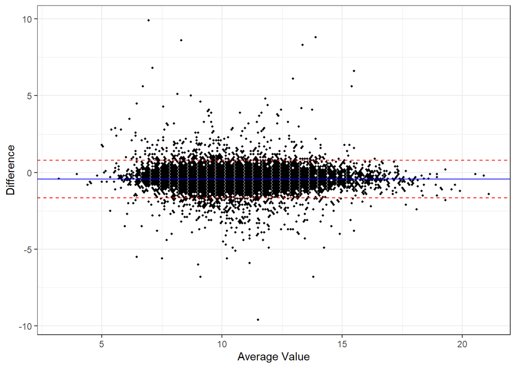

```r
ba.all <- performBlandAltmanANalysis(
  df = cbc.bg,
  PN = c('CBC', 'BG'),
  DPT = c('PICU', 'CICU'),
  to.graph = T,
  to.return = T,
  non.param = NA
)
```

```
## Number of rows from which correlation is calculated: 6062
```

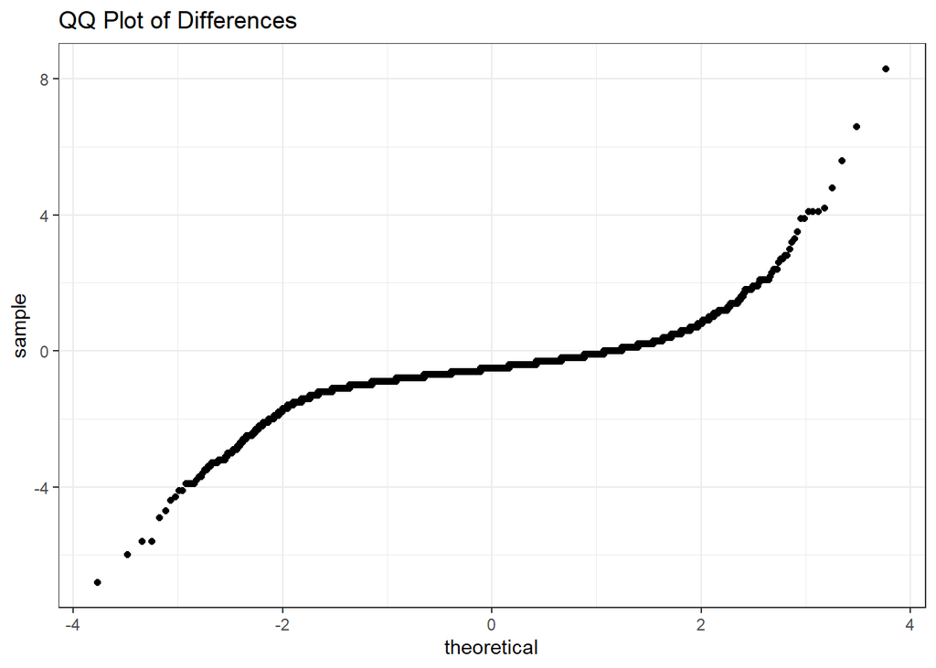

```
## B-A Analysis of CBC - BG in DEPT PICU
##  Mean difference (bias): -0.4925
## Limits: [-1.76, 0.78]
## CIs of mean and limits:
## lower.limit.ci.lower lower.limit.ci.upper   mean.diff.ci.lower
##           -1.7910272           -1.7345021           -0.5088611
##   mean.diff.ci.upper upper.limit.ci.lower upper.limit.ci.upper
##           -0.4762263            0.7494147            0.8059397
```

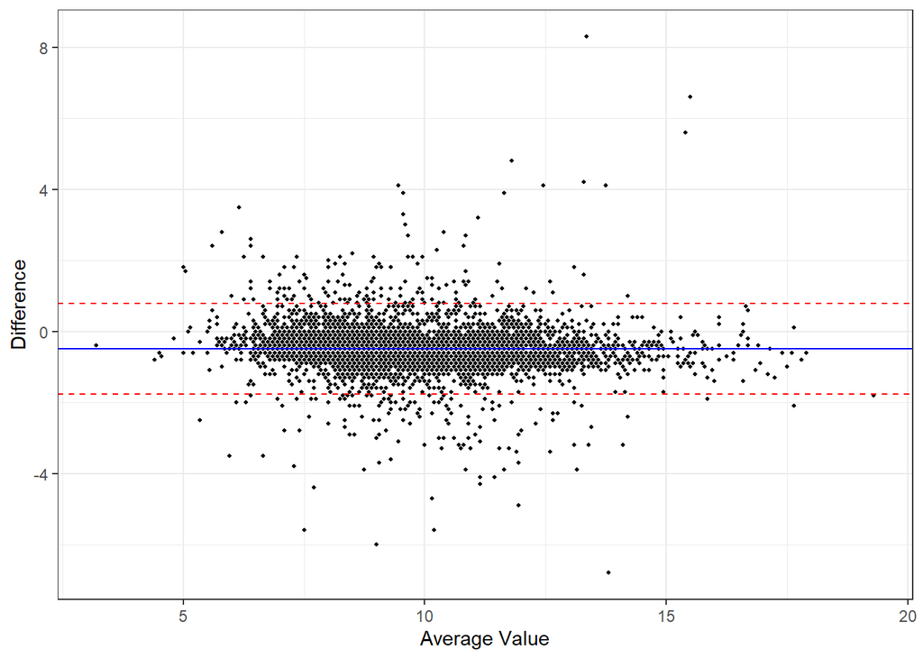

```r
ba.picu <- performBlandAltmanANalysis(
  df = cbc.bg,
  PN = c('CBC', 'BG'),
  DPT = 'PICU',
  to.graph = T,
  to.return = T
)
```

```
## Number of rows from which correlation is calculated: 12618
```

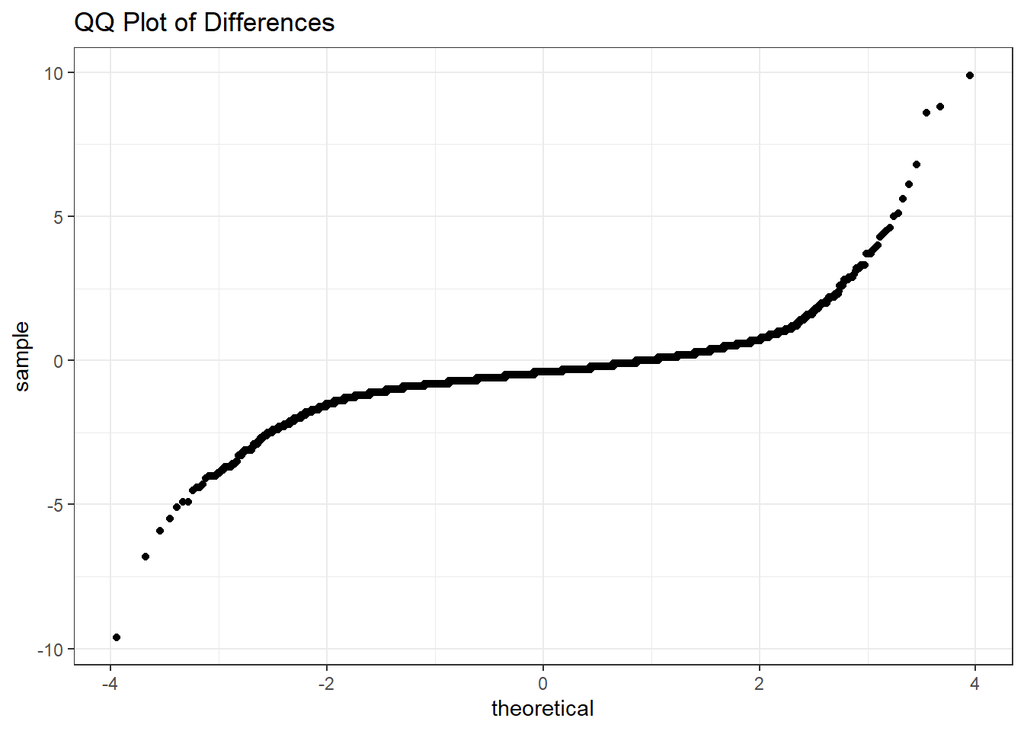

```
## B-A Analysis of CBC - BG in DEPT CICU
##  Mean difference (bias): -0.4024
## Limits: [-1.61, 0.81]
## CIs of mean and limits:
## lower.limit.ci.lower lower.limit.ci.upper   mean.diff.ci.lower
##           -1.6288777           -1.5916266           -0.4131627
##   mean.diff.ci.upper upper.limit.ci.lower upper.limit.ci.upper
##           -0.3916558            0.7868081            0.8240592
```

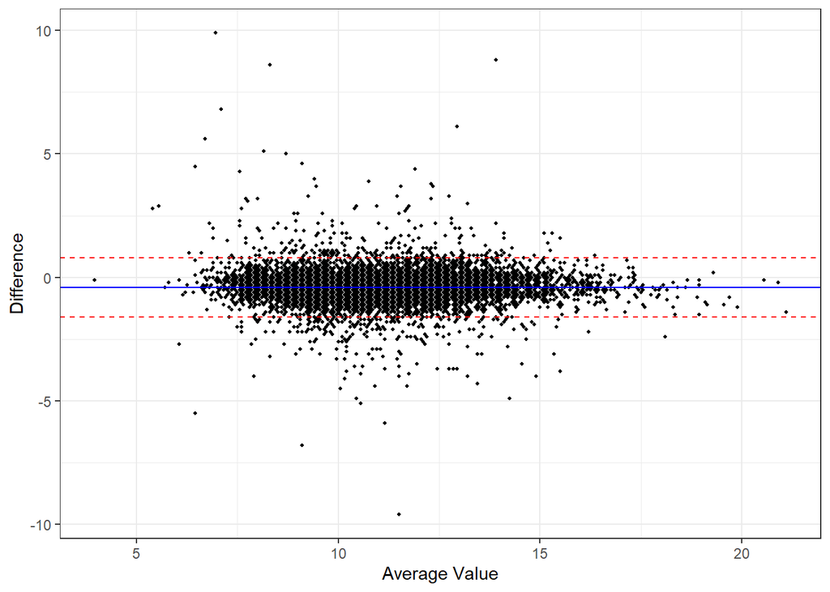

```r
ba.cicu <- performBlandAltmanANalysis(
  df = cbc.bg,
  PN = c('CBC', 'BG'),
  DPT = 'CICU',
  to.graph = T,
  to.return = T
)
```

Based on non-normally distributed differences, run non-parametric B-A by limiting percentiles for analysis:

```
## Number of rows from which correlation is calculated: 18680
## Lower 2.50 %: -1.500 Upper 97.50 %: 0.700
## New number of rows: 17759
```

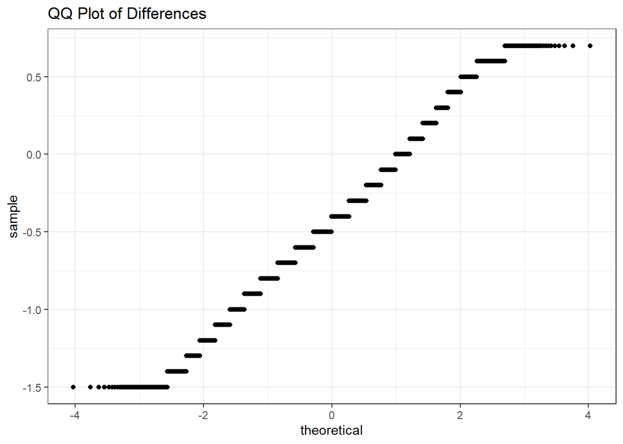

```
## B-A Analysis of CBC - BG in DEPT PICU
##  B-A Analysis of CBC - BG in DEPT CICU
##  Mean difference (bias): -0.4334
## Limits: [-1.21, 0.34]
## CIs of mean and limits:
## lower.limit.ci.lower lower.limit.ci.upper   mean.diff.ci.lower
##           -1.2196583           -1.1994814           -0.4392330
##   mean.diff.ci.upper upper.limit.ci.lower upper.limit.ci.upper
##           -0.4275838            0.3326646            0.3528415
```

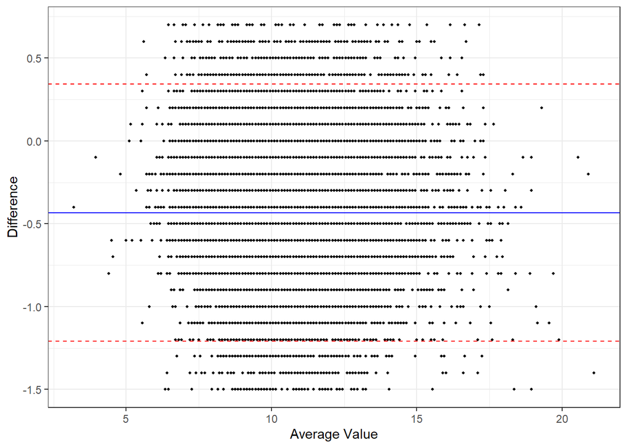

```r
ba.all.non.param <- performBlandAltmanANalysis(
  df = cbc.bg,
  PN = c('CBC', 'BG'),
  DPT = c('PICU', 'CICU'),
  to.graph = T,
  to.return = T,
  non.param = c(0.025, 0.975)
)
```

### Time To Result

Next we describe the differences in time-to-result, which is the difference between resulted time and collected time:

```r
#'
#' @title Describe Time To Result
#'
#' @description Compares and describes the time to result between PROCs
#'
#' @param df The labs data frame
#' @param PN A 2-element list of the PROC NAMEs
#' @param WILCOX.CI If TRUE, computes Wilcoxon signed rank confidence intervals
#'
#' @returns A list containing the plot and Wilcoxon results
#'
#'
describeTimeToResult <- function (df, PN, WILCOX.CI = F) {

  # Create the Time-To-Result data frame
  time_to_result <-
    rbind(
      data.frame(
        TTR = as.numeric(df$RESULT_DT.x - df$COLLECTED_DT.x, units = 'mins'),
        SRC = PN[1]
      ),
      data.frame(
        TTR = as.numeric(df$RESULT_DT.y - df$COLLECTED_DT.y, units = 'mins'),
        SRC = PN[2]
      )
    )

  ttr.quint <- quantile(time_to_result$TTR, c(0.01, 0.99))

  # Set the colors on the panel
  panel.colors <- RColorBrewer::brewer.pal(3,"Set1")

  src.vec <- vector()
  src.vec[[PN[1]]] <- panel.colors[1]
  src.vec[[PN[2]]] <- panel.colors[2]

  # Plot
  TTR.p <-
    time_to_result %>%
    dplyr::filter(TTR > ttr.quint[1] & TTR <= ttr.quint[2]) %>%
    ggplot() +
    geom_density(aes(x = TTR, fill = SRC), alpha = 0.5) +
    scale_fill_manual(values = src.vec) +
    coord_cartesian(xlim = c(0, 150)) +
    xlab('Time To Result (Resulted - Collected Timestamp, min)') +
    ylab('Density') +
    labs(fill = 'Source') +
    theme_bw()

  print(TTR.p)

  # Display summary statistics
  cat(sprintf('Summary of Time-To-Result for %s\n', PN[1]))
  print(summary(time_to_result$TTR[time_to_result$SRC == PN[1]]))

  cat(sprintf('Summary of Time-To-Result for %s\n', PN[2]))
  print(summary(time_to_result$TTR[time_to_result$SRC == PN[2]]))

  # Determine normality
  p1 <-
    time_to_result %>%
    dplyr::filter(SRC == PN[1]) %>%
    ggplot(aes(sample = TTR)) +
    stat_qq() +
    ggtitle(paste0('TTR QQ Plot: ',PN[1])) +
    theme_bw()

  print(p1)

  p2 <-
    time_to_result %>%
    dplyr::filter(SRC == PN[2]) %>%
    ggplot(aes(sample = TTR)) +
    stat_qq() +
    ggtitle(paste0('TTR QQ Plot: ',PN[2])) +
    theme_bw()

  print(p2)

  # Determine significant difference by non-parametric Wilcoxon signed rank test
  # Note that we use paired statistics here because these are paired samples
  wilcox.res <-
    wilcox.test(
      x = time_to_result$TTR[time_to_result$SRC == PN[1]],
      y = time_to_result$TTR[time_to_result$SRC == PN[2]],
      alternative = 'two.sided',
      paired = TRUE,
      conf.int = WILCOX.CI
    )

  print(wilcox.res)

  # Return
  return(list(
    plot = TTR.p,
    wilcox.res = wilcox.res
  ))
}
```

Capture the graphic so that we can save it out:

```r
TTR.p <- describeTimeToResult(
  df = cbc.bg,
  PN = c('CBC', 'BG'),
  WILCOX.CI = F
)
```

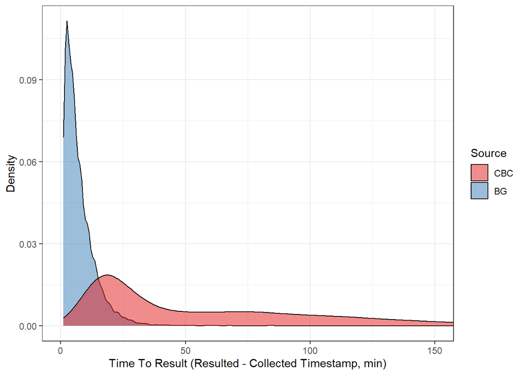

```
## Summary of Time-To-Result for CBC
##     Min.  1st Qu.   Median     Mean  3rd Qu.     Max.
##  -233.00    20.00    42.00    88.74    92.00 12611.00
## Summary of Time-To-Result for BG
##    Min. 1st Qu.  Median    Mean 3rd Qu.    Max.
##   -4.00    2.00    5.00   15.09    9.00 8706.00
```

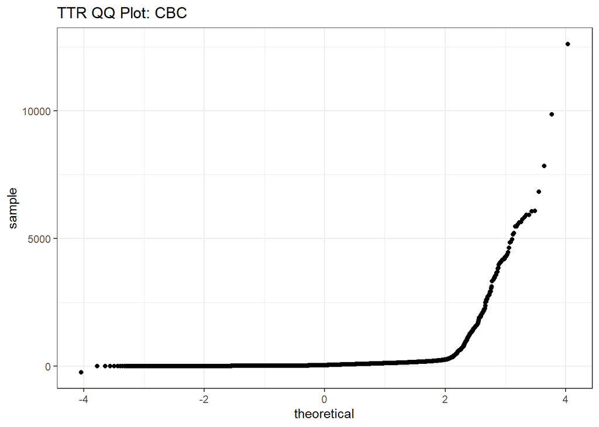

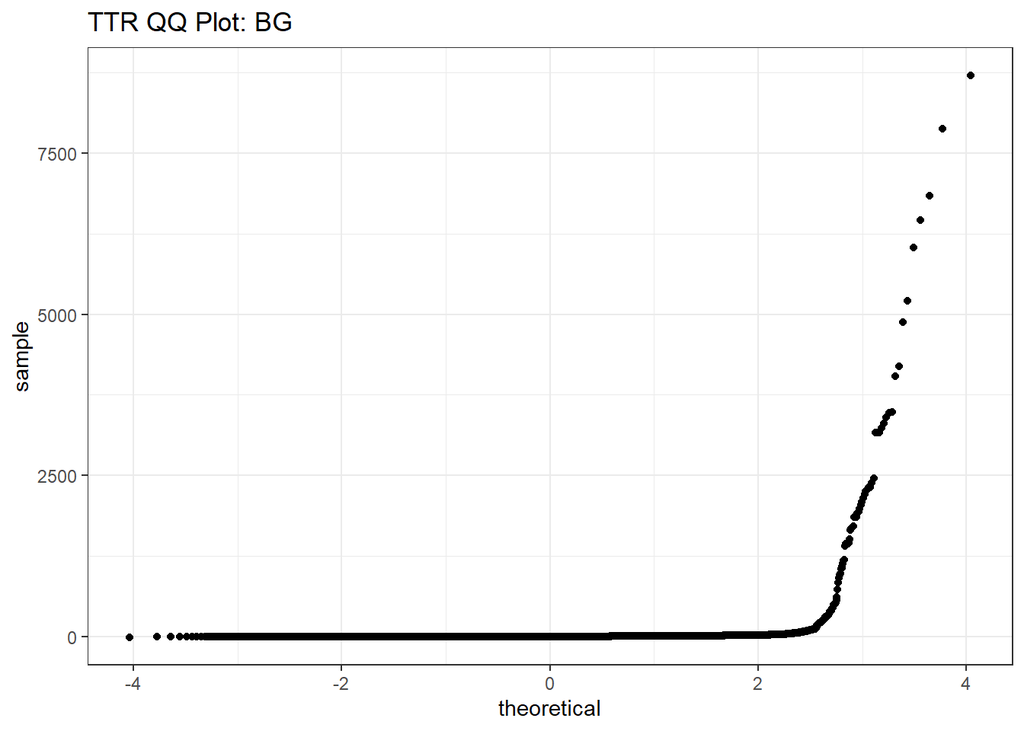

```
##
##  Wilcoxon signed rank test with continuity correction
##
## data:  time_to_result$TTR[time_to_result$SRC == PN[1]] and time_to_result$TTR[time_to_result$SRC == PN[2]]
## V = 169453307, p-value < 2.2e-16
## alternative hypothesis: true location shift is not equal to 0
```

### Save Out

Save out our primary cutoff analytic data, for use when combining with other sites.

```r
save(
  file = file.path(
    Sys.getenv('PICU_LAB_DATA_PATH'),
    paste0(
      Sys.getenv('PICU_LAB_SITE_NAME'),
      '_pri_cbc_bg_analytic_',
      run.date, '.rData'
    )
  ),
  primary.cutoff,
  paired.res,
  pcc.cbc.bg, pcc.cbc.bg.picu, pcc.cbc.bg.cicu,
  ba.all, ba.picu, ba.cicu, ba.all.non.param,
  TTR.p
)
```

## CBC vs ISTAT

If the lab results data frame contains ISTAT results, we must also complete those analyses. Using the functions written above, all of those are collapsed into a single function (below). Inside this function we:

- Create the paired dataset from the labs data frame
- Count values by department
- Describe the paired distribtions
- Determine correlations
- Calculate time-to-result (though this is *not* used in POC tests)
- Save data file

```r
#'
#' @title Run All Analytic
#'
#' @description Runs through all analytic analyses, for sensitivity analyses
#'
#' @param labs.df The original labs data frame
#' @param cohort.df The original cohort data frame
#' @param compare.PN The comparison PROC name (e.g. either `BG` or `ISTAT`)
#' @param time.diff The cutoff time difference (in minutes) for determining
#'     whether labs are "simultaneous"
#' @param multi.per.pt If TRUE, allows all results from patients;
#'     If FALSE, only the first (chronological) result from a patient is included
#' @param run.date A string representation of date for saving (format: %Y-%m-%d)
#' @param save.fn The file name (which will be concatenated with SITE and run.date),
#'     or NA [Default] if we do not wish to save any results to a file
#'
runAllAnalytic <- function (labs.df, cohort.df, compare.PN,
                         time.diff, multi.per.pt, run.date, save.fn = NA) {

  # Create paired dataset
  paired.df <- createPairedDataset(
    labs.df = labs.df,
    cohort.df = cohort.df,
    PN = c('CBC', compare.PN),
    CN = 'Hgb',
    time.diff = time.diff,
    multi.per.pt = multi.per.pt
  )

  # Counts by department
  print(table(paired.df$DEPT))

  # Describe paired distribution
  paired.res <- describePairedDistributions(
    df = paired.df,
    PN = c('CBC', compare.PN),
    paired.t = T,
    to.return = T
  )

  # Correlations
  pcc <- determineCorrelation(paired.df, c('PICU', 'CICU'))
  pcc.picu <- determineCorrelation(paired.df, 'PICU')
  pcc.cicu <- determineCorrelation(paired.df, 'CICU')

  cat(sprintf('PICU (R: %0.4f) vs CICU (R: %0.4f): %0.4f\n',
              pcc.picu$cor.est,
              pcc.cicu$cor.est,
              comparePearsonCorrelations(
                r1 = pcc.picu$cor.est,
                n1 = pcc.picu$n,
                r2 = pcc.cicu$cor.est,
                n2 = pcc.cicu$n
              )))

  # Bland Altman Analysis
  ba.all <- performBlandAltmanANalysis(
    df = paired.df,
    PN = c('CBC', compare.PN),
    DPT = c('PICU', 'CICU'),
    to.graph = T,
    to.return = T
  )

  ba.picu <- performBlandAltmanANalysis(
    df = paired.df,
    PN = c('CBC', compare.PN),
    DPT = 'PICU',
    to.graph = T,
    to.return = T
  )

  ba.cicu <- performBlandAltmanANalysis(
    df = paired.df,
    PN = c('CBC', compare.PN),
    DPT = 'CICU',
    to.graph = T,
    to.return = T
  )

  # Bland Altman Analysis
  ba.all.non.param <- performBlandAltmanANalysis(
    df = paired.df,
    PN = c('CBC', compare.PN),
    DPT = c('PICU', 'CICU'),
    to.graph = T,
    to.return = T,
    non.param = c(0.025, 0.0975)
  )

  # Time-to-result
  TTR.p <- describeTimeToResult(
    df = paired.df,
    PN = c('CBC', compare.PN),
    WILCOX.CI = F
  )

  # Save out?
  if (! any(is.na(save.fn)) ) {
    save(
      file = file.path(
        Sys.getenv('PICU_LAB_DATA_PATH'),
        paste0(
          Sys.getenv('PICU_LAB_SITE_NAME'),
          '_', save.fn, '_',
          run.date, '.rData'
        )
      ),
      time.diff, multi.per.pt,
      paired.res,
      pcc, pcc.picu, pcc.cicu,
      ba.all, ba.picu, ba.cicu, ba.all.non.param,
      TTR.p
    )
  }
}
```

Now we run for the POC values using the primary cutoff, allowing all results per patient (if the PROC exists):

```r
if ('ISTAT' %in% unique(labs.df$PROC_NAME)) {

  runAllAnalytic(
    labs.df,
    cohort.df,
    compare.PN = 'ISTAT',
    time.diff = primary.cutoff,
    multi.per.pt = T,
    run.date = run.date,
    save.fn = 'pri_cbc_istat_analytic'
  )

}
```

## Sensitivity Analyses

Now we complete some of the same above measures using different permutations, as sensitivity analyses.

### Single Value per Patient

First we change the parameters to require a single value per patient. We run this across both BG and ISTAT pairs (if they exist).

```r
for (proc.option in c('BG', 'ISTAT')) {

  if (proc.option %in% unique(labs.df$PROC_NAME)) {

    runAllAnalytic(
      labs.df,
      cohort.df,
      compare.PN = proc.option,
      time.diff = primary.cutoff,
      multi.per.pt = F, # This is the change in this section
      run.date = run.date,
      save.fn = paste0('single_pt_cbc_', tolower(proc.option), '_analytic')
    )

  }
}
```

```
## Number of component numeric rows in input data frame: 173682
## Number of paired, simultaneous values meeting cutoff: 19532
## Number of non-duplicated first PROC_NAME rows: 18684
## Number of non-duplicated second PROC_NAME rows: 18680
## Number of paired, simultaneous values: 2439
## Number of duplicated ORDER_PROC_KEY.x values: 0
##
## CICU PICU
## 1363 1076
## Summary of CBC values:
##    Min. 1st Qu.  Median    Mean 3rd Qu.    Max.
##    3.00    9.60   11.00   11.13   12.50   20.80
## SD: 2.28
```

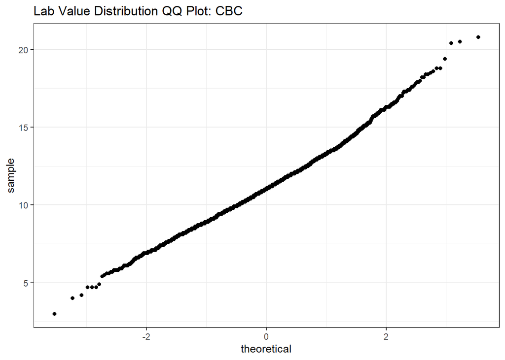

```
## Summary of BG values:
##    Min. 1st Qu.  Median    Mean 3rd Qu.    Max.
##    2.00   10.10   11.50   11.55   12.95   21.80
## SD: 2.29
```

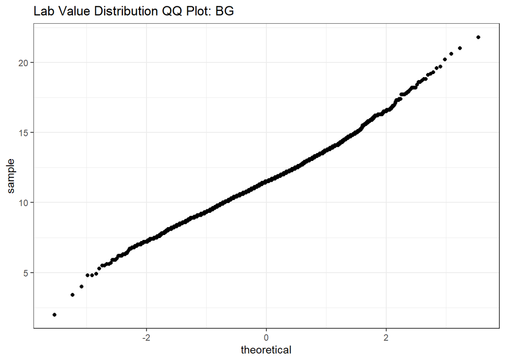

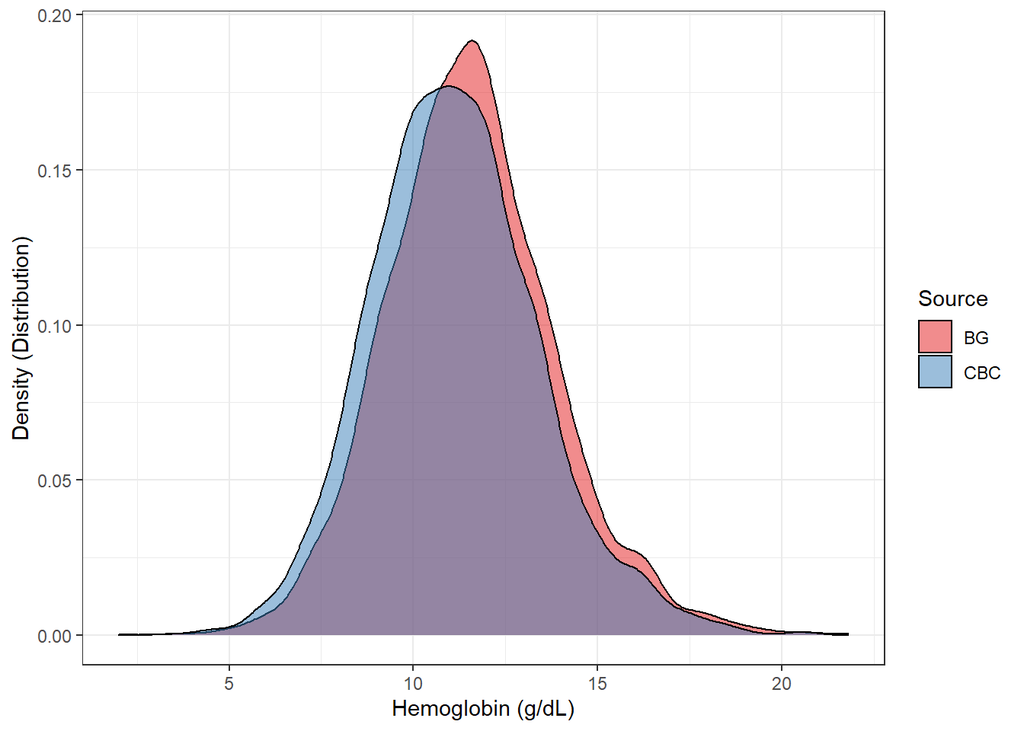

```
##
##  Paired t-test
##
## data:  df$NUM_VAL.x and df$NUM_VAL.y
## t = -29.964, df = 2438, p-value < 2.2e-16
## alternative hypothesis: true difference in means is not equal to 0
## 95 percent confidence interval:
##  -0.4531741 -0.3975024
## sample estimates:
## mean of the differences
##              -0.4253383
##
## Number of rows from which correlation is calculated: 2439
## First we use `cor` function to calculate:
##  Correlation (R): 0.9530 R^2: 0.9083
##  CI: Lower: 0.9012   Upper: 0.9153
## Now we use `cor.test` and `conf.int` to calculate:
##  Calculated R: 0.9530    R^2: 0.9083
##  Calulated CIs: Lower: 0.9011    Upper: 0.9150
## Number of rows from which correlation is calculated: 1076
## First we use `cor` function to calculate:
##  Correlation (R): 0.9545 R^2: 0.9110
##  CI: Lower: 0.9007   Upper: 0.9213
## Now we use `cor.test` and `conf.int` to calculate:
##  Calculated R: 0.9545    R^2: 0.9110
##  Calulated CIs: Lower: 0.9003    Upper: 0.9206
## Number of rows from which correlation is calculated: 1363
## First we use `cor` function to calculate:
##  Correlation (R): 0.9452 R^2: 0.8934
##  CI: Lower: 0.8825   Upper: 0.9043
## Now we use `cor.test` and `conf.int` to calculate:
##  Calculated R: 0.9452    R^2: 0.8934
##  Calulated CIs: Lower: 0.8822    Upper: 0.9036
## PICU (R: 0.9545) vs CICU (R: 0.9452): 0.0201
## Number of rows from which correlation is calculated: 2439
```

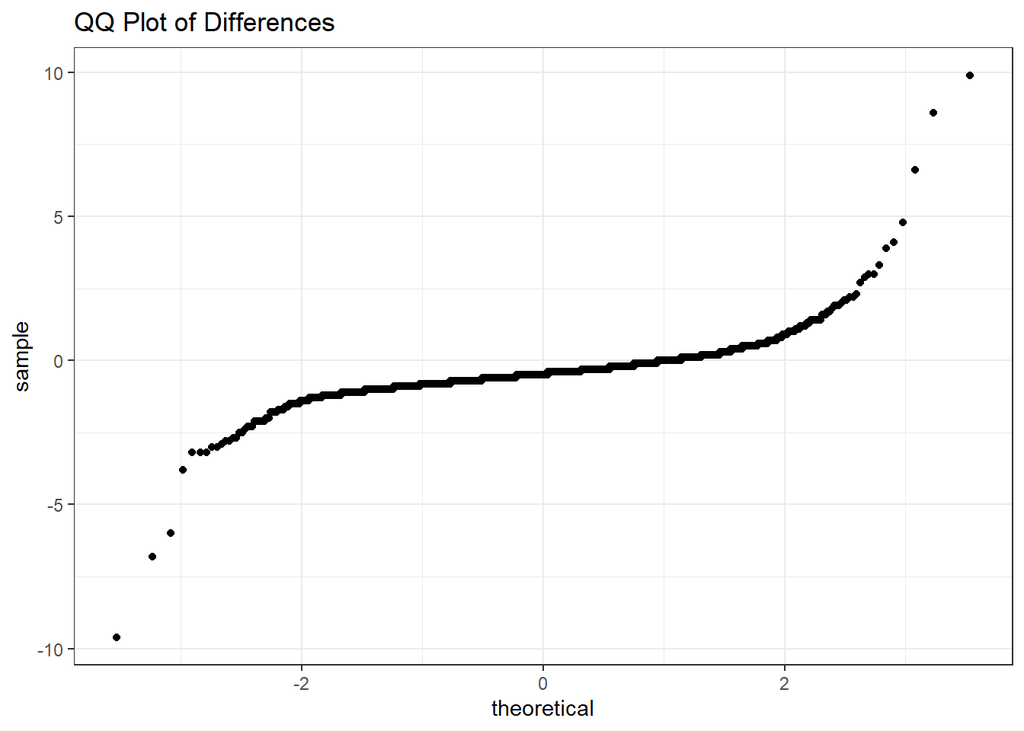

```
##
##  Shapiro-Wilk normality test
##
## data:  limited.df$diff
## W = 0.70796, p-value < 2.2e-16
##
## B-A Analysis of CBC - BG in DEPT PICU
##  B-A Analysis of CBC - BG in DEPT CICU
##  Mean difference (bias): -0.4253
## Limits: [-1.80, 0.95]
## CIs of mean and limits:
## lower.limit.ci.lower lower.limit.ci.upper   mean.diff.ci.lower
##           -1.8476022           -1.7511760           -0.4531741
##   mean.diff.ci.upper upper.limit.ci.lower upper.limit.ci.upper
##           -0.3975024            0.9004995            0.9969257
```

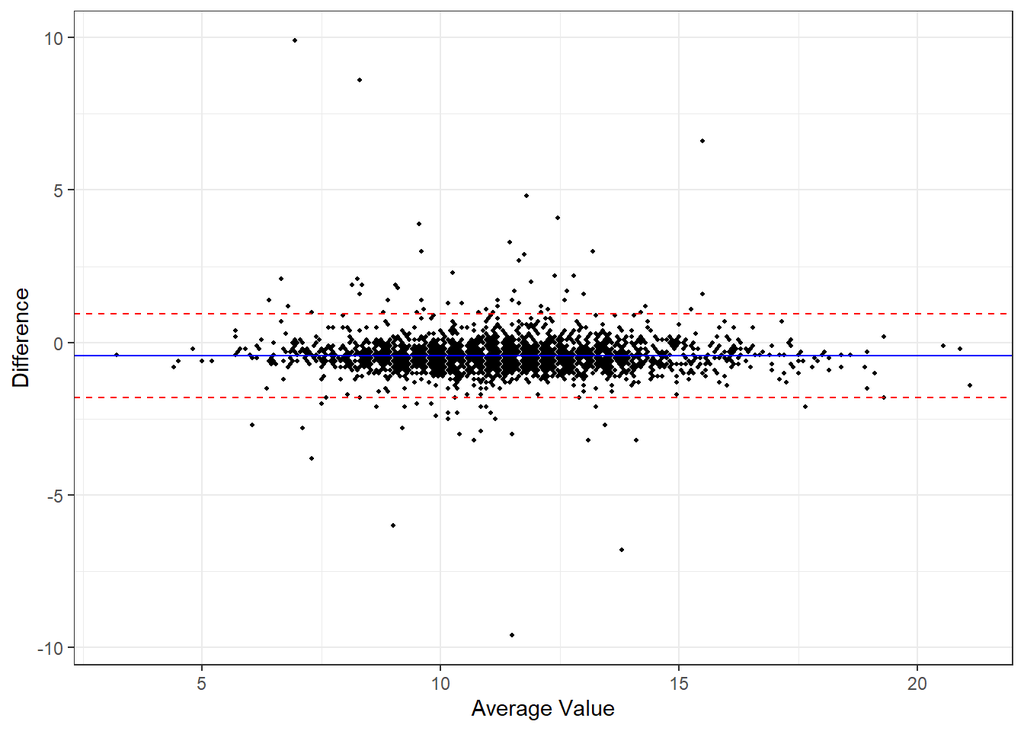

```
## Number of rows from which correlation is calculated: 1076
```

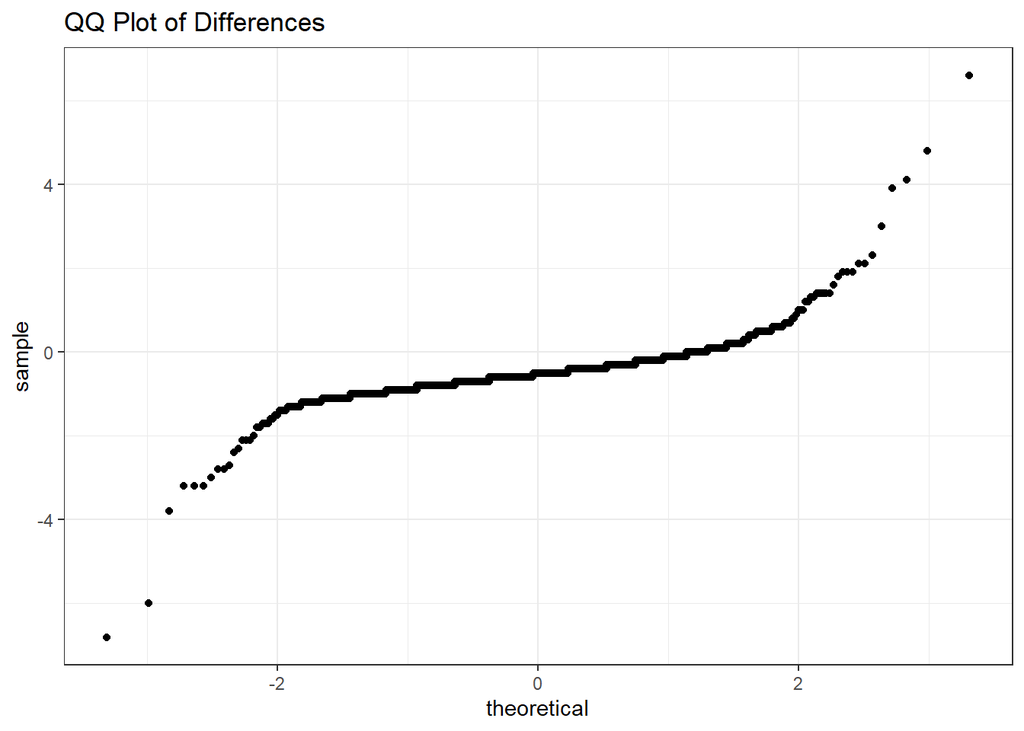

```
##
##  Shapiro-Wilk normality test
##
## data:  limited.df$diff
## W = 0.72285, p-value < 2.2e-16
##
## B-A Analysis of CBC - BG in DEPT PICU
##  Mean difference (bias): -0.4903
## Limits: [-1.85, 0.86]
## CIs of mean and limits:
## lower.limit.ci.lower lower.limit.ci.upper   mean.diff.ci.lower
##           -1.9169088           -1.7736606           -0.5316868
##   mean.diff.ci.upper upper.limit.ci.lower upper.limit.ci.upper
##           -0.4489824            0.7929915            0.9362396
```

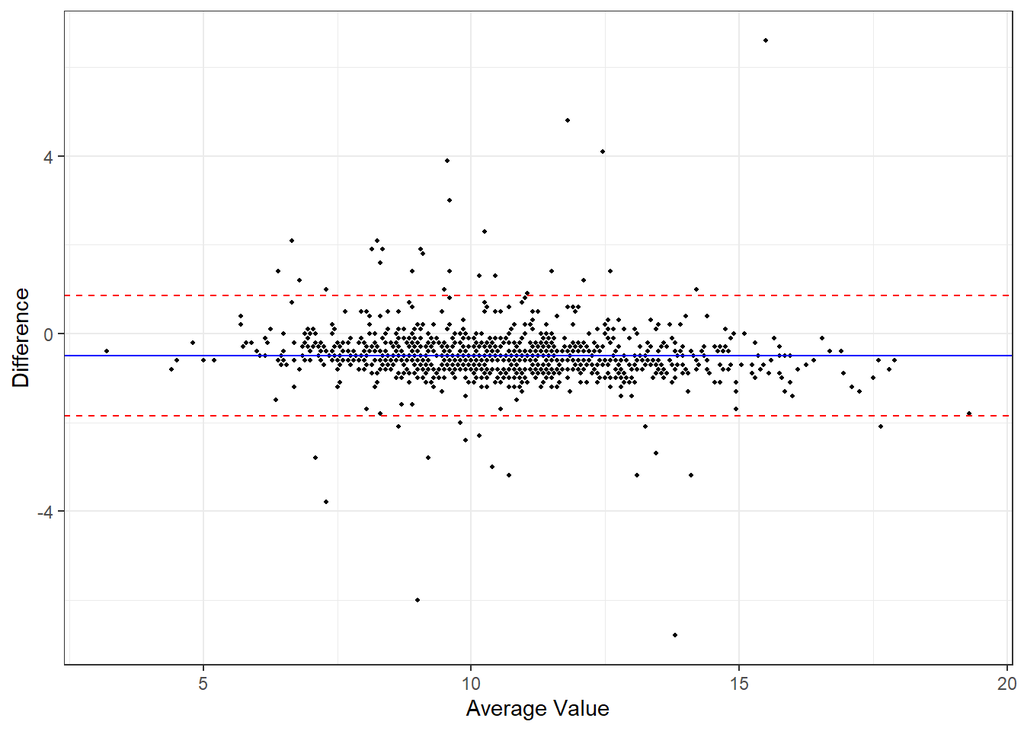

```
## Number of rows from which correlation is calculated: 1363
```

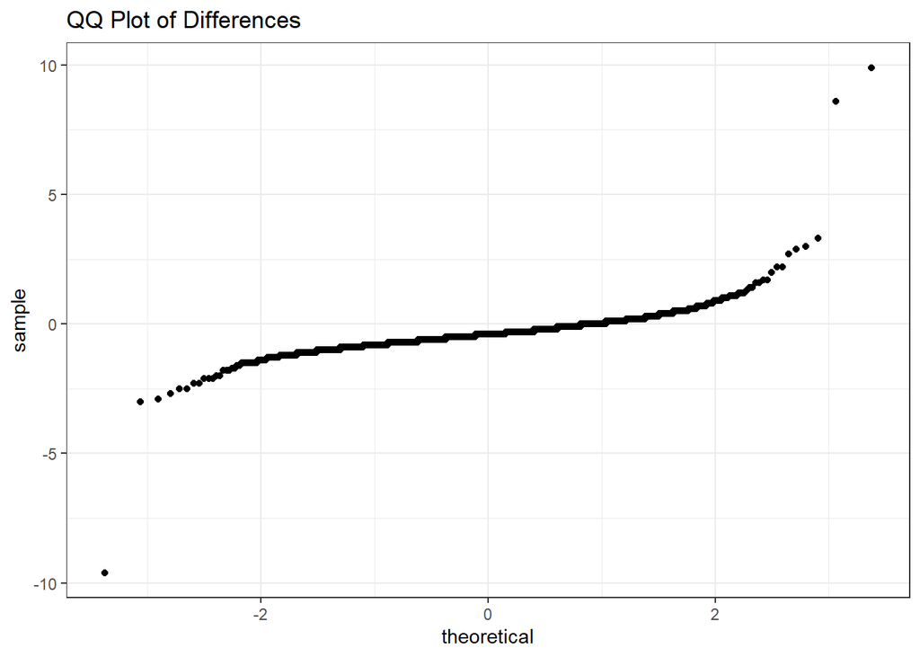

```
##
##  Shapiro-Wilk normality test
##
## data:  limited.df$diff
## W = 0.68496, p-value < 2.2e-16
##
## B-A Analysis of CBC - BG in DEPT CICU
##  Mean difference (bias): -0.3740
## Limits: [-1.76, 1.01]
## CIs of mean and limits:
## lower.limit.ci.lower lower.limit.ci.upper   mean.diff.ci.lower
##           -1.8200410           -1.6903337           -0.4114712
##   mean.diff.ci.upper upper.limit.ci.lower upper.limit.ci.upper
##           -0.3365846            0.9422779            1.0719853
```

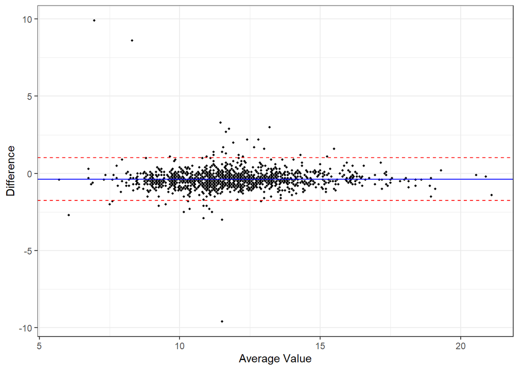

```
## Number of rows from which correlation is calculated: 2439
## Lower 2.50 %: -1.400 Upper 9.75 %: -1.000
## New number of rows: 202
```

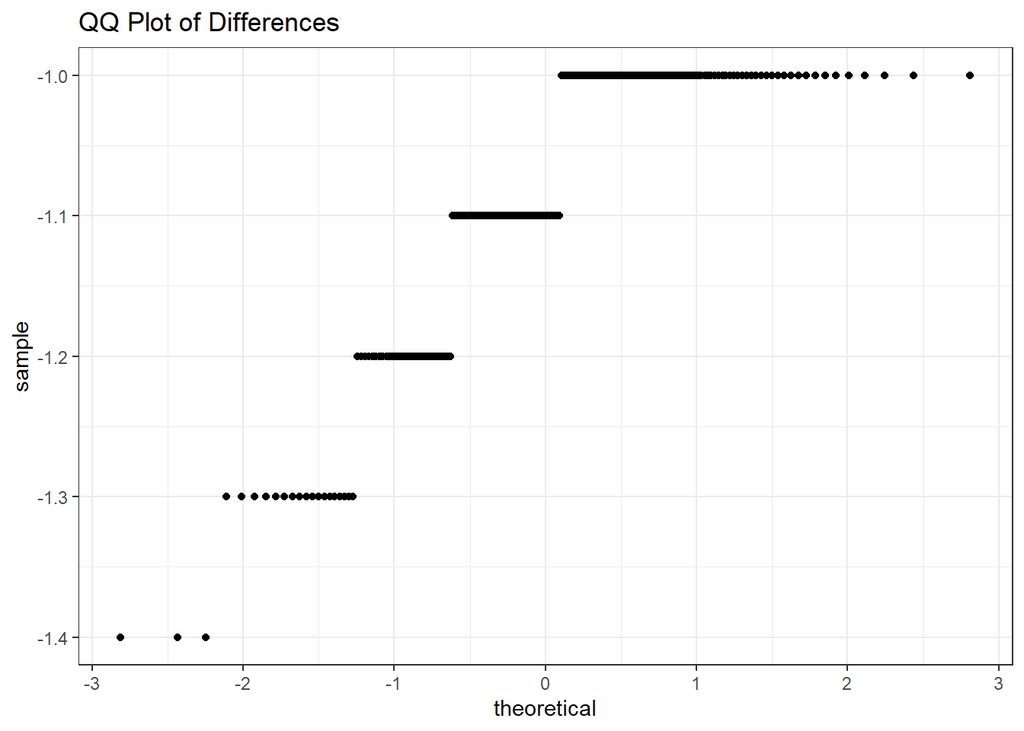

```
##
##  Shapiro-Wilk normality test
##
## data:  limited.df$diff
## W = 0.80425, p-value = 3.417e-15
##
## B-A Analysis of CBC - BG in DEPT PICU
##  B-A Analysis of CBC - BG in DEPT CICU
##  Mean difference (bias): -1.0926
## Limits: [-1.30, -0.89]
## CIs of mean and limits:
## lower.limit.ci.lower lower.limit.ci.upper   mean.diff.ci.lower
##           -1.3247932           -1.2740706           -1.1072166
##   mean.diff.ci.upper upper.limit.ci.lower upper.limit.ci.upper
##           -1.0779319           -0.9110779           -0.8603553
```

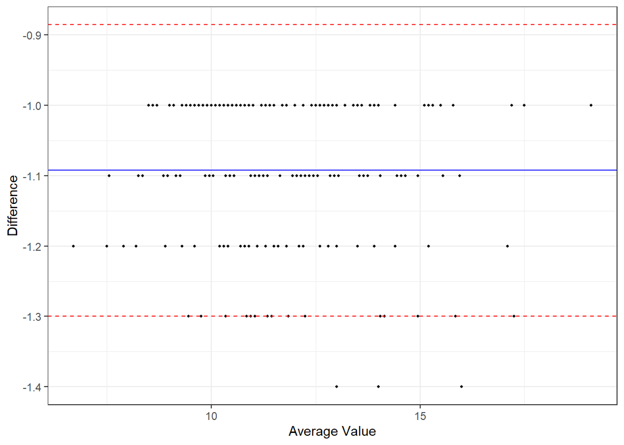

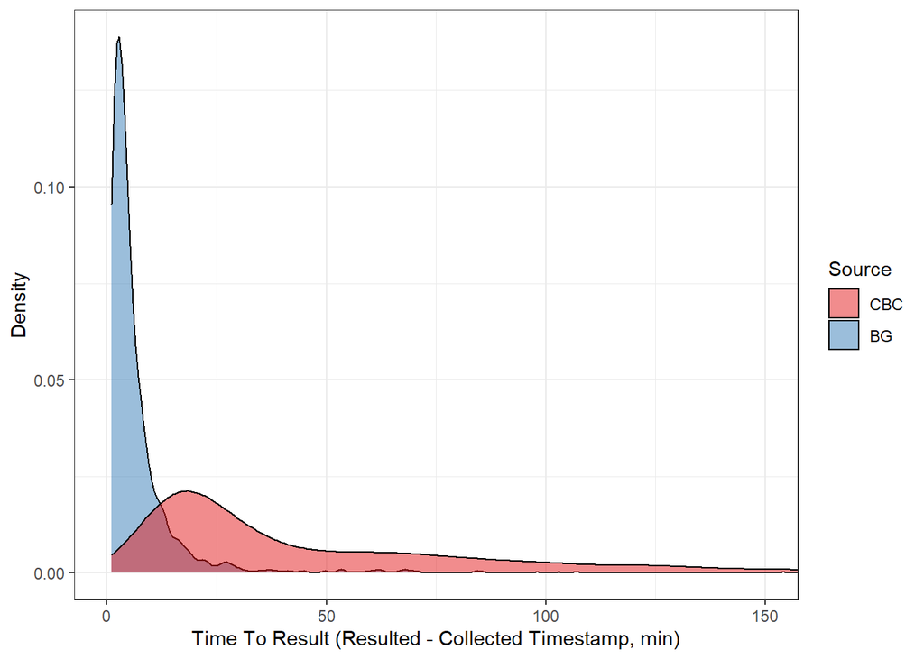

```
## Summary of Time-To-Result for CBC
##    Min. 1st Qu.  Median    Mean 3rd Qu.    Max.
##     3.0    18.0    30.0    69.2    70.0  7831.0
## Summary of Time-To-Result for BG
##    Min. 1st Qu.  Median    Mean 3rd Qu.    Max.
##   -2.00    2.00    4.00   25.62    7.00 8706.00
```

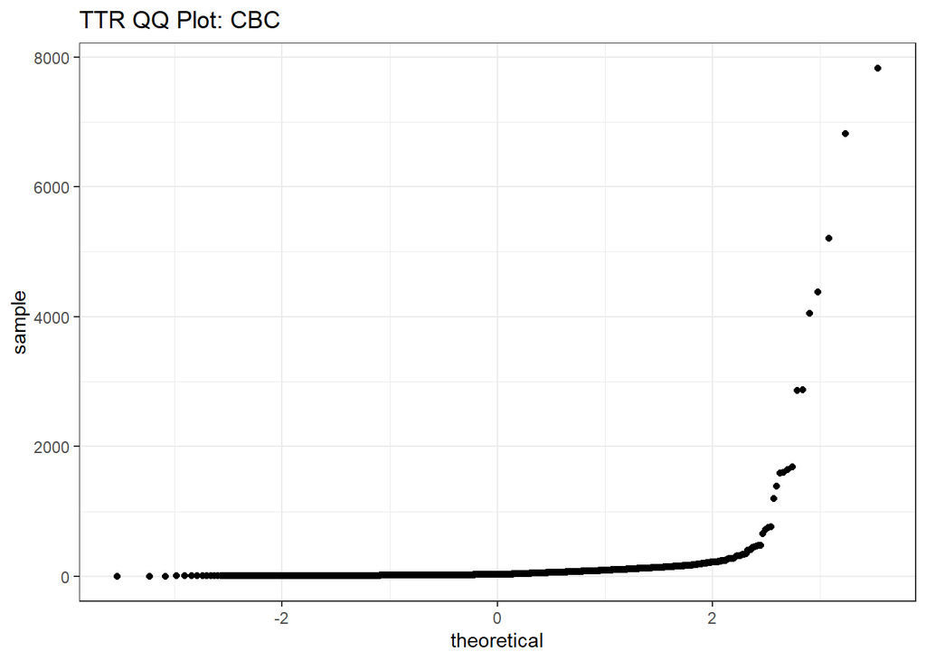

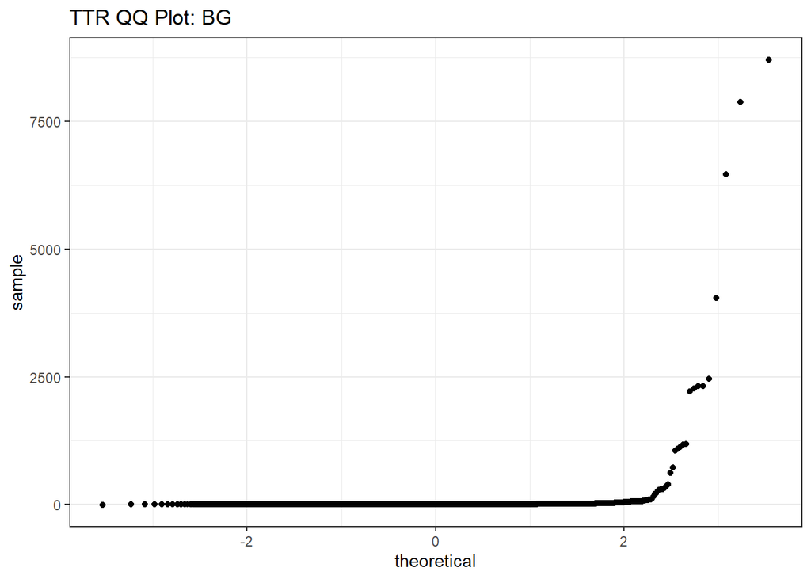

```
##
##  Wilcoxon signed rank test with continuity correction
##
## data:  time_to_result$TTR[time_to_result$SRC == PN[1]] and time_to_result$TTR[time_to_result$SRC == PN[2]]
## V = 2840010, p-value < 2.2e-16
## alternative hypothesis: true location shift is not equal to 0
```

### Time Threshold

Now we change parameters to alter the cutoff (min) between labs that get counted as “simultaneous” labs. We revert back to allowing multiple values per patient. We run this across both BG and ISTAT pairs (if they exist), across all `sens.cutoffs` values.

```r
for (cutoff in sens.cutoffs) {

  for (proc.option in c('BG', 'ISTAT')) {

    if (proc.option %in% unique(labs.df$PROC_NAME)) {

      runAllAnalytic(
        labs.df,
        cohort.df,
        compare.PN = proc.option,
        time.diff = cutoff,
        multi.per.pt = T,
        run.date = run.date,
        save.fn = NA
      )

    } # If the PROC exists

  } # Across BG vs ISTAT

} # Across cutoffs
```

```
## Number of component numeric rows in input data frame: 173682
## Number of paired, simultaneous values meeting cutoff: 9849
## Number of non-duplicated first PROC_NAME rows: 9572
## Number of non-duplicated second PROC_NAME rows: 9572
## Number of paired, simultaneous values: 9572
## Number of duplicated ORDER_PROC_KEY.x values: 0
##
## CICU PICU
## 6757 2815
## Summary of CBC values:
##    Min. 1st Qu.  Median    Mean 3rd Qu.    Max.
##    3.70    8.90   10.20   10.37   11.60   20.80
## SD: 1.95
```

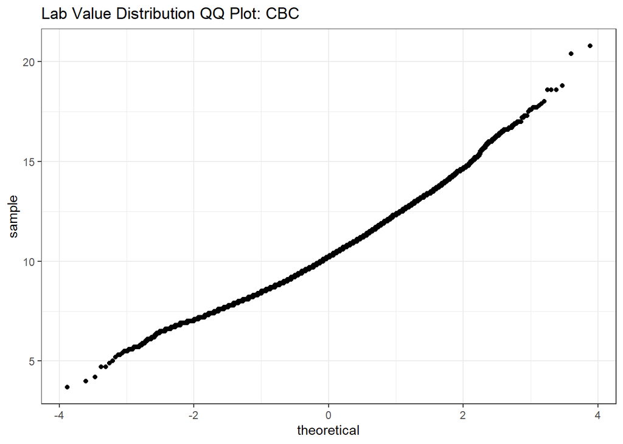

```
## Summary of BG values:
##    Min. 1st Qu.  Median    Mean 3rd Qu.    Max.
##    2.00    9.40   10.70   10.82   12.00   21.80
## SD: 1.95
```

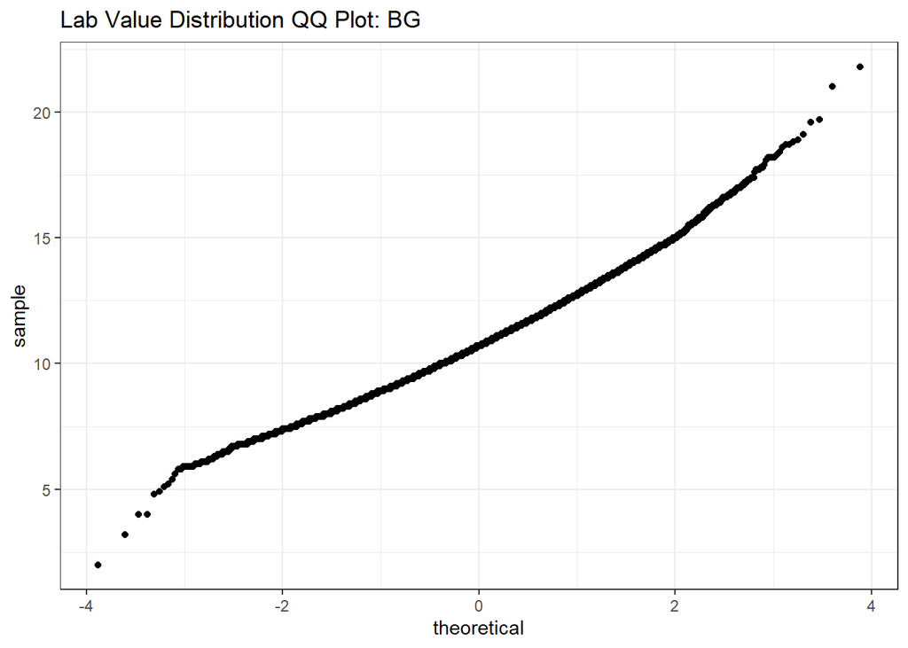

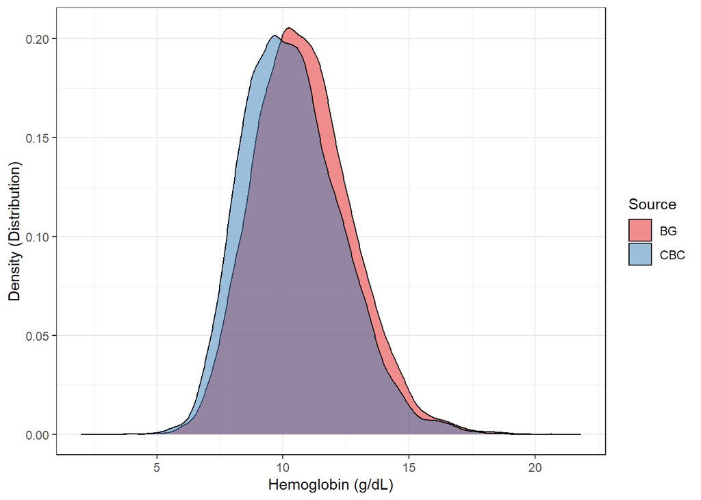

```
##
##  Paired t-test
##
## data:  df$NUM_VAL.x and df$NUM_VAL.y
## t = -72.069, df = 9571, p-value < 2.2e-16
## alternative hypothesis: true difference in means is not equal to 0
## 95 percent confidence interval:
##  -0.4547492 -0.4306666
## sample estimates:
## mean of the differences
##              -0.4427079
##
## Number of rows from which correlation is calculated: 9572
## First we use `cor` function to calculate:
##  Correlation (R): 0.9526 R^2: 0.9074
##  CI: Lower: 0.9038   Upper: 0.9110
## Now we use `cor.test` and `conf.int` to calculate:
##  Calculated R: 0.9526    R^2: 0.9074
##  Calulated CIs: Lower: 0.9038    Upper: 0.9109
## Number of rows from which correlation is calculated: 2815
## First we use `cor` function to calculate:
##  Correlation (R): 0.9467 R^2: 0.8963
##  CI: Lower: 0.8889   Upper: 0.9037
## Now we use `cor.test` and `conf.int` to calculate:
##  Calculated R: 0.9467    R^2: 0.8963
##  Calulated CIs: Lower: 0.8888    Upper: 0.9033
## Number of rows from which correlation is calculated: 6757
## First we use `cor` function to calculate:
##  Correlation (R): 0.9497 R^2: 0.9019
##  CI: Lower: 0.8974   Upper: 0.9065
## Now we use `cor.test` and `conf.int` to calculate:
##  Calculated R: 0.9497    R^2: 0.9019
##  Calulated CIs: Lower: 0.8974    Upper: 0.9063
## PICU (R: 0.9467) vs CICU (R: 0.9497): 0.1901
## Number of rows from which correlation is calculated: 9572
```